# Recap 2020-04-07

## 5. Next steps - qualitative insights - oil spills

### By individual spills

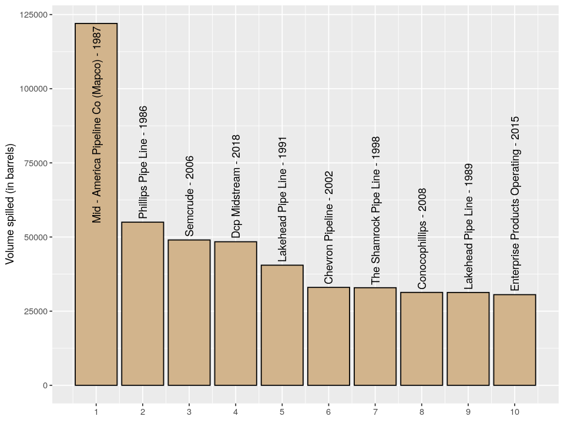

```r
top_volume
```

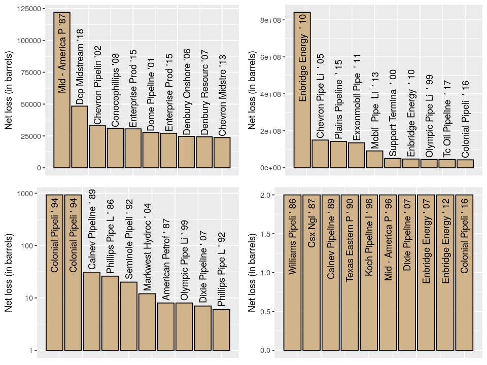

```r
grid::grid.draw(top_grid)
```

**Next step: Picking up the largest incidents here and create spider charts**

### By individual pipelines

```r
keystone_candidates <- subset(incidents_2010, ID == 32334)

keystone_candidates$long <- as.numeric(keystone_candidates$long)
keystone_candidates$lat <- as.numeric(keystone_candidates$lat)

# maps_key <- readChar("../../maps_key.txt", file.info("../../maps_key.txt")$size)
# register_google(maps_key)
# us <- ggmap::get_googlemap("US", zoom = 4)
# saveRDS(us, "../us_map.rds")
us <- readRDS("../resources/us_map.rds")

keystone_operator_spills <- ggmap(us) +
    geom_point(data = keystone_candidates, aes(x=long, y=lat, size = volume), alpha = 0.5)
```

[figure not shown]

```r
keystone_operator_spills
```

[figure not shown]

The pipeline - for comparison.

### By learning processes

[figure not shown]

*Source: Draft Environmental Impact Assessment, DNV Consulting 2006.*

[figure not shown]

*Source: Draft Environmnental Impact Assessment, DNV Consulting 2006.*

In other words, the operator expects **one significant spill every 7 years** from the get-go.

## 6. Developing empirical questions

### Backdrop - learning literature

Going steady - especially through latest writing initiative

### The problem at hand

- I am interested in the environmental impact
- But the numbers are not readily interpretable/comparable

Commonplace proble in research?

### In general

1. Progress as outcome of experience
2. Ownership
3. Progress as outcome of rare events/failure
4. Qualitative route - incident reports and (non-)progress